```python
#librerias
import numpy as np
import pandas as pd
import matplotlib.pyplot as plt
import scipy.stats as stats
import statsmodels.stats.diagnostic as diag
import statsmodels.api as sm
from sklearn.preprocessing import StandardScaler
from sklearn.model_selection import train_test_split
from sklearn.metrics import precision_score, accuracy_score, recall_score, f1_score, confusion_matrix
from sklearn.neighbors import KNeighborsClassifier, NearestNeighbors
import seaborn as sns
import re
import random
from scipy.spatial.distance import cdist
import pyclustertend
import sklearn.preprocessing
from sklearn.decomposition import PCA
from mpl_toolkits.mplot3d import Axes3D
import sklearn.cluster as cluster
from sklearn.cluster import KMeans
from sklearn.datasets import make_blobs
```

```python
#cargar los datos
df = pd.read_csv("movies.csv", encoding="latin1")
```

# 1. Exploración de datos

```python
#exploracion de los datos
#mostrar las columanas
print("\n--Columnas:---")
print(list(df.columns))

#resumen del set de datos
print("\n--Resumen del set de datos:--")
print(df.describe())
```

```
--Columnas:---
['id', 'budget', 'genres', 'homePage', 'productionCompany', 'productionCompanyCountry', 'productionCountry', 'revenue', 'runtime', 'video', 'director', 'actors', 'actorsPopularity', 'actorsCharacter', 'originalTitle', 'title', 'originalLanguage', 'popularity', 'releaseDate', 'voteAvg', 'voteCount', …

--Resumen del set de datos:--
                  id        budget       revenue       runtime    popularity  \
count   10000.000000  1.000000e+04  1.000000e+04  10000.000000  10000.000000
mean   249876.829300  1.855163e+07  5.673793e+07    100.268100     51.393907
std    257380.109004  3.662669e+07  1.495854e+08     27.777829    216.729552
min         5.000000  0.000000e+00  0.000000e+00      0.000000      4.258000
25%     12286.500000  0.000000e+00  0.000000e+00     90.000000     14.577750
50%    152558.000000  5.000000e+05  1.631245e+05    100.000000     21.905500
75%    452021.750000  2.000000e+07  4.479661e+07    113.000000     40.654000
max    922260.000000  3.800000e+08  2.847246e+09    750.000000  11474.647000

            voteAvg     voteCount  genresAmount  productionCoAmount  \
count  10000.000000  10000.000000  10000.000000        10000.000000
mean       6.483490   1342.381800      2.596500            3.171400
std        0.984274   2564.196637      1.154565            2.539738
min        1.300000      1.000000      0.000000            0.000000
25%        5.900000    120.000000      2.000000            2.000000
50%        6.500000    415.000000      3.000000            3.000000
75%        7.200000   1316.000000      3.000000            4.000000
max       10.000000  30788.000000     16.000000           89.000000

       productionCountriesAmount   actorsAmount
count               10000.000000   10000.000000
mean                    1.751000    2147.666600
std                     3.012093   37200.075802
min                     0.000000       0.000000
25%                     1.000000      13.000000
50%                     1.000000      21.000000
75%                     2.000000      36.000000
max                   155.000000  919590.000000
```

```python
#obtener el tipo de datos
print("\n----Tipo de datos:---")
print(df.dtypes)
tipos_de_datos = df.dtypes.value_counts()
print('resumen:')
print(tipos_de_datos)
```

```
----Tipo de datos:---
id                             int64
budget                         int64
genres                        object
homePage                      object
productionCompany             object
productionCompanyCountry      object
productionCountry             object
revenue                      float64
runtime                        int64
video                         object
director                      object
actors                        object
actorsPopularity              object
actorsCharacter               object
originalTitle                 object
title                         object
originalLanguage              object
popularity                   float64
releaseDate                   object
voteAvg                      float64
voteCount                      int64
genresAmount                   int64
productionCoAmount             int64
productionCountriesAmount      int64
actorsAmount                   int64
castWomenAmount               object
castMenAmount                 object
dtype: object
resumen:
object     16
int64       8
float64     3
Name: count, dtype: int64
```

# 2. Tipo de variables

### Variables:

1. Id: Id de la película
2. popularity: Índice de popularidad de la película calculado semanalmente
3. budget: El presupuesto para la película.
4. revenue: El ingreso de la película.
5. original_title: El título original de la película, en su idioma original.
6. originalLanguage: Idioma original en que se encuentra la película
7. title: El título de la película traducido al inglés
8. homePage: La página de inicio de la película
9. video: Si tiene videos promocionales o no
10. director: Director de la película
11. runtime: La duración de la película.
12. genres: El género de la película.
13. genresAmount: Cantidad de géneros que representan la película
14. productionCompany: Las compañías productoras de la película.
15. productionCoAmount: Cantidad de compañías productoras que participaron en la película
16. productionCompanyCountry: Países de las compañías productoras de la película
17. productionCountry: Países en los que se llevó a cabo la producción de la película
18. productionCountriesAmount: Cantidad de países en los que se rodó la película
19. releaseDate: Fecha de lanzamiento de la película
20. voteCount: El número de votos en la plataforma para la película.
21. voteAvg: El promedio de los votos en la plataforma para la película
22. actors: Actores que participan en la película (Elenco)
23. actorsPopularity: Índice de popularidad del elenco de la película.
24. actorsCharacter: Personaje que interpreta cada actor en la película
25. actorsAmount: Cantidad de personas que actúan en la película
26. castWomenAmount: Cantidad de actrices en el elenco de la película
27. castMenAmount: Cantidad de actores en el elenco de la película.

## Tipo de Varibles

### Variables Cualitativas:

#### Ordinales:

- No hay

#### Nominales:

- original_title
- originalLanguage
- title
- homePage
- director
- genres
- productionCompany
- productionCompanyCountry
- productionCountry
- video
- actors
- actorsCharacter

### Variables Cuantitativas:

#### Continuas:

- popularity
- revenue
- voteAvg

#### Discretas:

- Id
- releaseDate
- budget
- runtime
- genresAmount
- productionCoAmount
- productionCountriesAmount
- voteCount
- actorsPopularity
- actorsAmount
- castWomenAmount
- castMenAmount

```python
# revision de valores duplicados
print(df.duplicated().sum())
```

```
0
```

```python
# eliminar valores nulos o llenarlos con la media
df = df.dropna()

#llenar los valores nulos de video
df['video'].fillna('FALSE', inplace=True)

#calcular la media de solo las columnas numericas
mean_values = df.select_dtypes(include=[np.number]).mean()

#reemplazar valores nulos con la media
df.fillna(mean_values, inplace=True)
```

```python
#convertir los tipos de datos
#convertir la columna video a numerica
df['video'] = df['video'].apply(lambda x: 1 if str(x).upper() == 'TRUE' else 0)

#convertir la columna releaseDate a datetime
df['releaseDate'] = pd.to_datetime(df['releaseDate'])

#convertir las columnas popularity, revenue y voteAvg a enteros
df['popularity'] = df['popularity'].astype(int)
df['revenue'] = df['revenue'].astype(int)
df['voteAvg'] = df['voteAvg'].astype(int)

#asegurarse que todas las variables sean de tipo int
df['castWomenAmount'] = df['castWomenAmount'].astype(int)
df['castMenAmount'] = df['castMenAmount'].astype(int)

#asegurarse que runtime no tenga valores negativos
df['runtime'] = df['runtime'].apply(lambda x: x if x > 0 else 0)
# df[df['runtime'] >= 0 ] #elimina los valores negativos
if (df['runtime'] < 0).any():
    print("Aún hay valores negativos en 'runtime'.")
else:
    print("Todos los valores negativos en 'runtime' han sido corregidos.")
```

```
Todos los valores negativos en 'runtime' han sido corregidos.
```

```python
#limpiar los datos de la populariadad de actores
# Eliminar caracteres no numerricos y convertir a float e ignorar los nombres
def clean_popularity(popularity_list):
    numeric_values = []
    for value in popularity_list:
        try:
            numeric_values.append(float(re.sub(r'\D', '', value)))
        except ValueError:
            pass  # ignorar los xd
    return numeric_values

df['actorsPopularity'] = df['actorsPopularity'].str.split('|').apply(clean_popularity)

#promedio de popularidad
df['actorsPopularity_avg'] = df['actorsPopularity'].apply(lambda x: sum(x) / len(x) if x else 0)
print((df['actorsPopularity_avg']))
```

```
0       10386.160000
10       2820.183099
11       5757.305556
14       5035.864865
16       8124.315789
            ...
9955       41.800000
9968     1706.625000
9979     8349.208333
9982    13318.918919
9988     6537.390244
Name: actorsPopularity_avg, Length: 3507, dtype: float64
```

```python
#limpiar tambien genero
df['genres'] = df['genres'].str.split('|')
print(df['genres'])

print('generos princiales:')
df['genero_principal'] = df['genres'].apply(lambda x: x[0] if isinstance(x, list) and len(x) > 0 else None)
print(df['genero_principal'])
```

```
0                    [Crime, Comedy]
10      [Adventure, Fantasy, Action]
11                   [Action, Crime]
14                      [Drama, War]
16       [Animation, Comedy, Family]
                    ...
9955           [War, History, Drama]
9968                [Romance, Drama]
9979            [Music, Documentary]
9982                   [Documentary]
9988                        [Comedy]
Name: genres, Length: 3507, dtype: object
generos princiales:
0             Crime
10        Adventure
11           Action
14            Drama
16        Animation
           ...
9955            War
9968        Romance
9979          Music
9982    Documentary
9988         Comedy
Name: genero_principal, Length: 3507, dtype: object
```

```python
#normalizacion de datos
#no se deben de normalizar todos los dato, entonces los de
#nobmres de las columans que no se van a normalizar, porque no es necesario
#columans que si se van a normalizar
numeric_columns = ['actorsAmount', 'runtime']
print(numeric_columns)
#normalizar los datos
scaler = StandardScaler()
df[numeric_columns] = scaler.fit_transform(df[numeric_columns])
print(df.head())
```

```
['actorsAmount', 'runtime']
    id     budget                        genres  \
0    5    4000000               [Crime, Comedy]
10  22  140000000  [Adventure, Fantasy, Action]
11  24   30000000               [Action, Crime]
14  28   31500000                  [Drama, War]
16  35   75000000   [Animation, Comedy, Family]

                                             homePage  \
0           https://www.miramax.com/movie/four-rooms/
10  http://disney.go.com/disneyvideos/liveaction/p...
11    http://www.miramax.com/movie/kill-bill-volume-1
14                       http://www.apocalypsenow.com
16                      http://www.simpsonsmovie.com/

```

[output cut: 36 more lines]

# Clustering

1.1 Preprocesamiento del dataset.

```
- Eliminar variables que no aportan información relevante.
- describir las variables con las que se calcularan los grupos
```

### variables que no aportan información relevante:

- Id, original_title, title, homePage porque son identificadores unicos, por lo tanto no aportan información relevante para la agrupación.
- actors: actores que participan en la película (Elenco), no es un factor determinante para la agrupación.
- director: puede influir bastante en la película, pero puede llegar a ser muy granular para la agrupacion. Por la gran variedad de directores diferentes entonces se puede tener grupos muy pequeños y que no representen algo significativo.
- actorsCharacter, actorsAmount, castWomenAmount, castMenAmount: también puede influir bastante en la película, pero puede llegar a ser muy granular para la agrupación. Por la gran variedad entonces se puede tener grupos muy pequeños y que no representen algo significativo.
- productionCompanyCountry, productionCountry, productionCoAmount, productionCountriesAmount: pueden influir bastante en la película, pero puede llegar a ser muy granular para la agrupación. Por la gran variedad entonces se puede tener grupos muy pequeños y que no representen algo significativo.

### Variables con las que se calcularan los grupos

Grupo seleccionado: caracteristica de peliculas existosas comercialmente:

- budget, revenue, popularity y genre

variables que podrían servir si se quisiera hacer un analisis más profundo (en este caso no se usarán más que genre, pero se agrega aquí como recomendación):

- genre, runtime, voteAvg, voteCount, releaseDate, video, actorsPopularity_avg, productionCompany

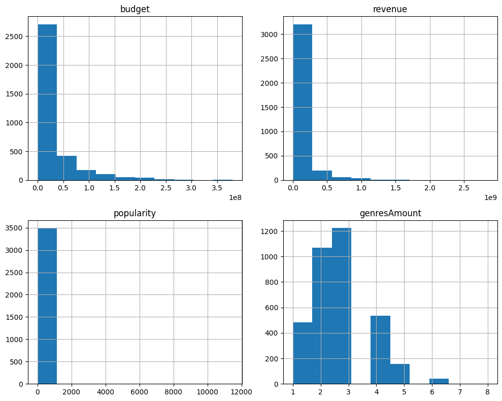

```python
#eliminar variables que no aportan informacion relevante
fig, axs = plt.subplots( figsize=(10, 8))
df.drop(['id', 'originalTitle', 'title', 'homePage', 'actors', 'director', 'actorsCharacter', 'actorsAmount', 'castWomenAmount', 'castMenAmount', 'productionCompanyCountry', 'productionCountry', 'productionCoAmount', 'productionCountriesAmount', 'runtime', 'voteAvg', 'voteCount', 'releaseDate', 'video', 'actorsPopularity', 'productionCompany', 'actorsPopularity_avg'], axis = 'columns' ).hist(ax=axs)
plt.tight_layout()
plt.show()
```

### 2.2 Tendencia de agrupamiento

```python
#estadistico de hopkings
#separar los datos numericos

numeric_columns = ['budget', 'popularity', 'revenue']
num_df = df[numeric_columns]
X_values = ['budget', 'popularity']
X = df[X_values]

y = df['revenue']

def hopkins(X):
    n = len(X)
    m = int(0.1 * n) # m es el numero de puntos random
    nbrs = NearestNeighbors(n_neighbors=m).fit(X) #fitting de los puntos
    rand_indices = np.random.randint(0, n, size =m) #indices random
    rand_X = X.iloc[rand_indices] #puntos random

    #distancia a los vecinos mas cercanos
    nn_dist = nbrs.kneighbors(rand_X, 2, return_distance=True)[0][:, 1]

    #distancia a un punto random
    rand_X_dist = np.random.rand(m, X.shape[1])
    min_dist = np.min(cdist(X, rand_X_dist), axis=1)

    #Calculo de hopkins
    ujd = sum(nn_dist)
    wjd = sum(min_dist)
    H = ujd / (ujd + wjd)

    return H
# #Aplicar el test de hopkins
# valor_hopkins= hopkins(X)
# print("El valor de Hopkins es: ", valor_hopkins)
#la funcion de hopkins que se habia creado, ya no se usara porque la libreria parece ser mas efectiva.

print('-'*15)


import random
import sklearn.preprocessing
# Fijar la semilla para obtener resultados reproducibles
random.seed(123)

# Escalar los datos para normalización
X_scale = sklearn.preprocessing.scale(X)
X_df =pd.DataFrame(X_scale)


# Crear muestras, esto se hace para tener una visualizacion mas clara y entender mejor la tendencia de agrupamiento
X_scale_sample = X_df.sample(100, random_state=123)
X_sample = X.sample(100, random_state=123)

# Convertir las muestras a arrays de numpy
X_scale_sample = X_scale_sample.to_numpy()
X_sample = X_sample.to_numpy()

# Calcular la estadística de Hopkins
hopkins_stat = pyclustertend.hopkins(X_scale, len(X_scale))
print(f'Estadística de Hopkins: {hopkins_stat}')
```

```
---------------
Estadística de Hopkins: 0.008056788294141921
```

En la estadística de Hopkins los valores que se encuentran cercanos a 0, indican que los datos estan muy agrupados, lo que sugiere que hay una estructura clara y que el clustering puede ser bastante efectivo.

```python
# #este grafico nos ayudaba a ver la tendencia de los datos, pero no se usara porque no es necesario y ya funciona VAT

# fig = plt.figure(figsize=(10,10))
# ax = fig.add_subplot(111, projection='3d')

# ax.scatter(num_df['budget'], num_df['popularity'], num_df['revenue'], cmap='viridis', c=df['revenue'])
# ax.scatter(num_df['budget'], num_df['popularity'], num_df['revenue'], cmap='viridis', c='blue')
# ax.set_xlabel('Presupuesto')
# ax.set_ylabel('Popularidad')
# ax.set_zlabel('Ingresos')

# plt.show()
# #lo que se logra visualizar aqui es la relacion entre presupuesto y popularidad usando los ingresos como altura
```

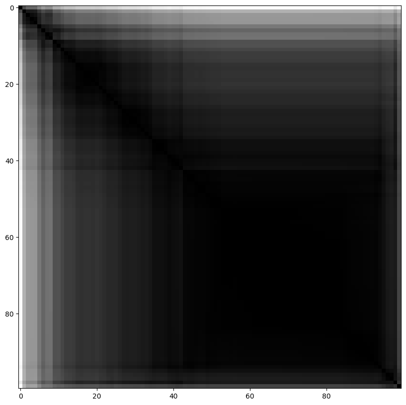

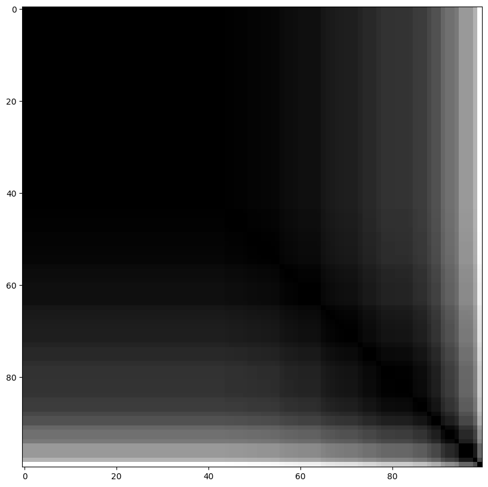

```python
# # VAT
pyclustertend.vat(X_scale_sample)

pyclustertend.vat(X_sample)
```

La gráfica VAT muestra una matriz de distancia, en donde los puntos representan la distancia entre los datos. La transición de negro a gris claro lo que nos indica es la intensidad de distancias. Siendo el negro distancias cortas y el gris claro distancias largas. Cuando hay áreas grandes de negro, lo que nos indica es que hay clusters muy cerca entre sí. Y se trabajó con una muestra de datos, ya que al usar todos los datos la visualización es bastante densa, por lo cual se decidió trabajar con una muestra de datos para poder visualizar mejor la gráfica.

### 1.3 determinar cual es el numero de grupos a formar mas adecuado para los datos. Realizar una grafica de codo y explicar la razon.

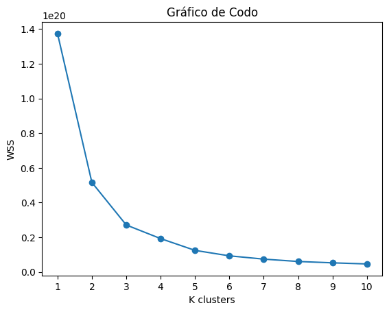

```python
#saber el numero de K clusters
numeroClusters = range(1,11)
wcss = []

for i in numeroClusters:
    kmeans = cluster.KMeans(n_clusters=i)
    kmeans.fit(num_df)
    wcss.append(kmeans.inertia_)

plt.plot(numeroClusters, wcss, marker='o')
plt.xticks(numeroClusters)
plt.xlabel("K clusters")
plt.ylabel("WSS")
plt.title("Gráfico de Codo")
plt.show()
```

Al analizar el grafico de codo, K=3 es un buen numero para los datos, ya que en la suma de wss disminuye rapidamente hasta 3 clusters y luego ya se vuelve mas gradual.

1.4 Algoritmos de k-medias y clustering jerarquico para agrupar

```python
#K medias
km = cluster.KMeans(n_clusters=3).fit(X)
print (km)
```

```
KMeans(n_clusters=3)
```

```python
centroides = km.cluster_centers_
print(centroides)
```

```
[[6.23950224e+07 1.05409712e+02]
 [6.18163975e+06 4.35676493e+01]
 [1.70370792e+08 3.06896040e+02]]
```

```python
#predecir
y_kmeans = km.predict(X)
print (y_kmeans)
```

```
[1 2 1 ... 1 1 1]
```

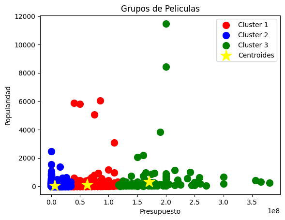

```python
plt.scatter(num_df.iloc[y_kmeans == 0]['budget'], num_df.iloc[y_kmeans == 0]['popularity'],
            s=100, c='red', label="Cluster 1")
plt.scatter(num_df.iloc[y_kmeans == 1]['budget'], num_df.iloc[y_kmeans == 1]['popularity'],
            s=100, c='blue', label="Cluster 2")
plt.scatter(num_df.iloc[y_kmeans == 2]['budget'], num_df.iloc[y_kmeans == 2]['popularity'],
            s=100, c='green', label="Cluster 3")

plt.scatter(km.cluster_centers_[:, 0], km.cluster_centers_[:, 1], s=300, c='yellow', marker='*', label='Centroides')

plt.title("Grupos de Peliculas")
plt.xlabel("Presupuesto")
plt.ylabel("Popularidad")
plt.legend()
```

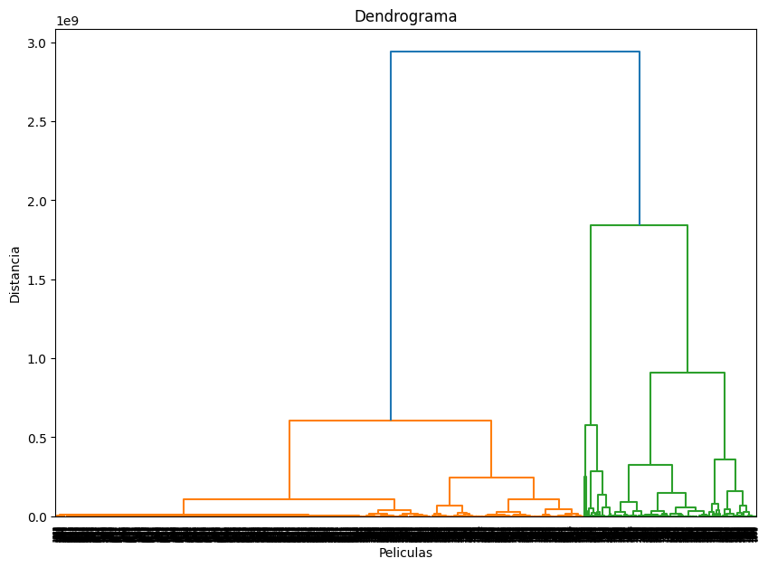

```python
#clustering jerargico
import scipy.cluster.hierarchy as shc
from scipy.spatial.distance import pdist

# #calcular la matriz de distancias
dist = pdist(X, metric = 'euclidean')
#dendograma
plt.figure(figsize=(10, 7))
linkage = shc.linkage(X, method='ward')
dendro = shc.dendrogram(linkage)
plt.title("Dendrograma")
plt.xlabel("Peliculas")
plt.ylabel("Distancia")
plt.show()
```

1.5 Determinar la calidad del agrupamiento hecho por cada algoritmo con el método de la silueta

```
For n_clusters = 2 The average silhouette_score is : 0.7840679384761963
For n_clusters = 3 The average silhouette_score is : 0.7413795751880723
For n_clusters = 4 The average silhouette_score is : 0.7130838030430167
For n_clusters = 5 The average silhouette_score is : 0.7072625371248772
For n_clusters = 6 The average silhouette_score is : 0.7124995005899755
```

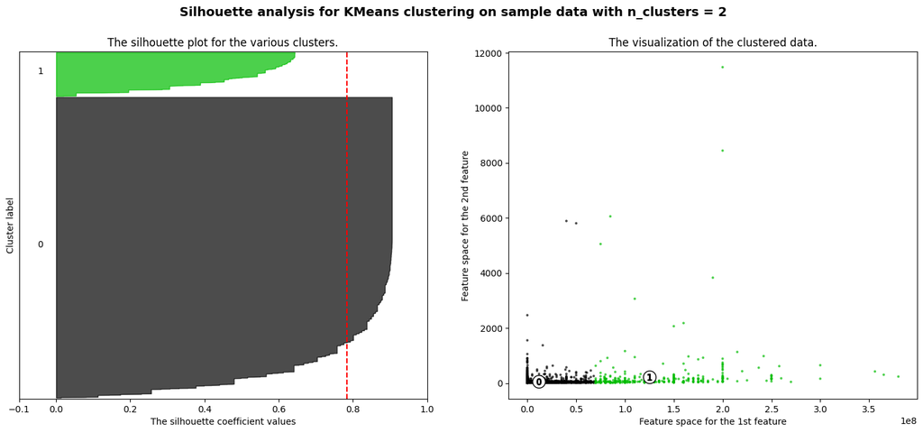

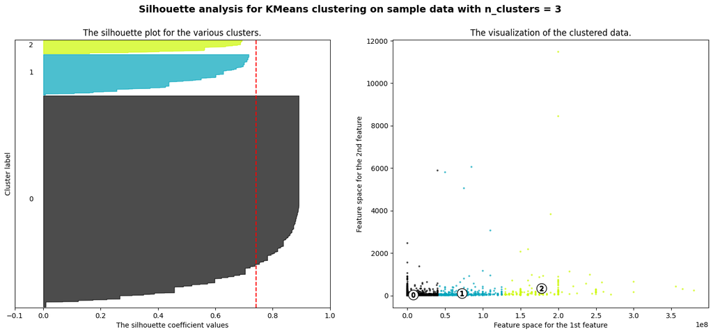

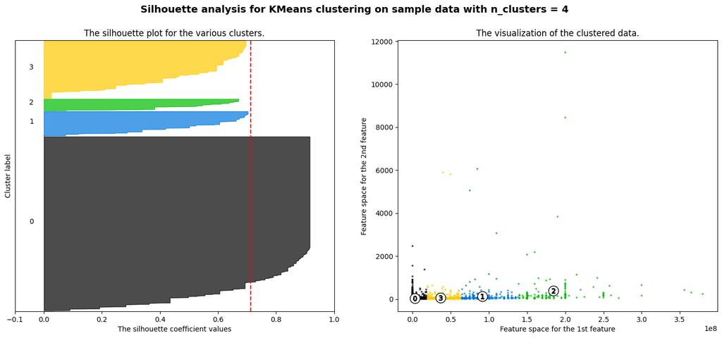

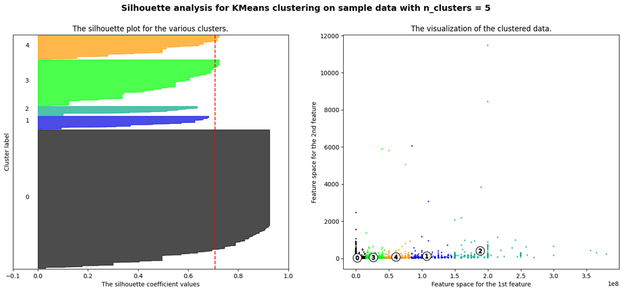

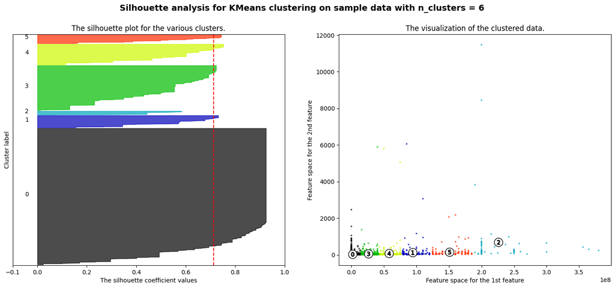

```python
'''
este algoritmo fue tomado del archivo que dice Clustering.ipynb de la carpeta de ejemplos en modulos de la clase
'''


from sklearn.datasets import make_blobs
from sklearn.cluster import KMeans
from sklearn.metrics import silhouette_samples, silhouette_score
import matplotlib.cm as cm
import matplotlib.pyplot as plt
import numpy as np

# convertir x en un np.array
X = X.values

range_n_clusters = [2, 3, 4, 5, 6]

for n_clusters in range_n_clusters:
    # Create a subplot with 1 row and 2 columns
    fig, (ax1, ax2) = plt.subplots(1, 2)
    fig.set_size_inches(18, 7)

    # The 1st subplot is the silhouette plot
    # The silhouette coefficient can range from -1, 1 but in this example all
    # lie within [-0.1, 1]
    ax1.set_xlim([-0.1, 1])
    # The (n_clusters+1)*10 is for inserting blank space between silhouette
    # plots of individual clusters, to demarcate them clearly.
    ax1.set_ylim([0, len(X) + (n_clusters + 1) * 10])

    # Initialize the clusterer with n_clusters value and a random generator
    # seed of 10 for reproducibility.
    clusterer = KMeans(n_clusters=n_clusters, random_state=10)
    cluster_labels = clusterer.fit_predict(X)

    # The silhouette_score gives the average value for all the samples.
    # This gives a perspective into the density and separation of the formed
    # clusters
    silhouette_avg = silhouette_score(X, cluster_labels)
    print(
        "For n_clusters =",
        n_clusters,
        "The average silhouette_score is :",
        silhouette_avg,
    )

    # Compute the silhouette scores for each sample
    sample_silhouette_values = silhouette_samples(X, cluster_labels)

    y_lower = 10
    for i in range(n_clusters):
        # Aggregate the silhouette scores for samples belonging to
        # cluster i, and sort them
        ith_cluster_silhouette_values = sample_silhouette_values[cluster_labels == i]

        ith_cluster_silhouette_values.sort()

        size_cluster_i = ith_cluster_silhouette_values.shape[0]
        y_upper = y_lower + size_cluster_i

        color = cm.nipy_spectral(float(i) / n_clusters)
        ax1.fill_betweenx(
            np.arange(y_lower, y_upper),
            0,
            ith_cluster_silhouette_values,
            facecolor=color,
            edgecolor=color,
            alpha=0.7,
        )

        # Label the silhouette plots with their cluster numbers at the middle
        ax1.text(-0.05, y_lower + 0.5 * size_cluster_i, str(i))

        # Compute the new y_lower for next plot
        y_lower = y_upper + 10  # 10 for the 0 samples

    ax1.set_title("The silhouette plot for the various clusters.")
    ax1.set_xlabel("The silhouette coefficient values")
    ax1.set_ylabel("Cluster label")

    # The vertical line for average silhouette score of all the values
    ax1.axvline(x=silhouette_avg, color="red", linestyle="--")

    ax1.set_yticks([])  # Clear the yaxis labels / ticks
    ax1.set_xticks([-0.1, 0, 0.2, 0.4, 0.6, 0.8, 1])

    # 2nd Plot showing the actual clusters formed
    colors = cm.nipy_spectral(cluster_labels.astype(float) / n_clusters)
    ax2.scatter(
        X[:, 0], X[:, 1], marker=".", s=30, lw=0, alpha=0.7, c=colors, edgecolor="k"
    )

    # Labeling the clusters
    centers = clusterer.cluster_centers_
    # Draw white circles at cluster centers
    ax2.scatter(
        centers[:, 0],
        centers[:, 1],
        marker="o",
        c="white",
        alpha=1,
        s=200,
        edgecolor="k",
    )

    for i, c in enumerate(centers):
        ax2.scatter(c[0], c[1], marker="$%d$" % i, alpha=1, s=50, edgecolor="k")

    ax2.set_title("The visualization of the clustered data.")
    ax2.set_xlabel("Feature space for the 1st feature")
    ax2.set_ylabel("Feature space for the 2nd feature")

    plt.suptitle(
        "Silhouette analysis for KMeans clustering on sample data with n_clusters = %d"
        % n_clusters,
        fontsize=14,
        fontweight="bold",
    )

plt.show()
```

El grafico de la silueta, lo que mide es que tan similar un punto a otros dentro del mismo cluster. Y este puede variar entre -1 a 1. Siendo un valor cercano a 1 indica que los puntos están bien agrupados dentro de sus propios clusters y lejos de otros clusters.

1.6 Interprete los grupos basado en el conocimiento que tiene de los datos. Recuerde investigar las medidas de tendencia central de las variables continuas y las tablas de frecuencia de las variables categóricas pertenecientes a cada grupo. Identifique hallazgos interesantes debido a las agrupaciones y describa para qué le podría servir.

```python
#medidas de tendencia centrar para variables continuas en cada cluster

#agregar la columna de cluster al dataframe

df['Cluster'] = kmeans.labels_
print(df.head())
```

```
    id     budget                        genres  \
0    5    4000000               [Crime, Comedy]
10  22  140000000  [Adventure, Fantasy, Action]
11  24   30000000               [Action, Crime]
14  28   31500000                  [Drama, War]
16  35   75000000   [Animation, Comedy, Family]

                                             homePage  \
0           https://www.miramax.com/movie/four-rooms/
10  http://disney.go.com/disneyvideos/liveaction/p...
11    http://www.miramax.com/movie/kill-bill-volume-1
14                       http://www.apocalypsenow.com
16                      http://www.simpsonsmovie.com/

                                    productionCompany  \
```

[output cut: 35 more lines]

```python
variables = ['budget', 'popularity', 'revenue']

for var in variables:
    print(f"Variable: {var}")
    print(df.groupby('Cluster')[var].describe())
    print("\n")
```

```
Variable: budget
          count          mean           std          min          25%  \
Cluster
0        2034.0  3.325620e+06  7.347301e+06          0.0          0.0
1          77.0  1.111032e+08  4.999301e+07    7000000.0   75000000.0
2          50.0  1.405900e+08  5.802741e+07   10500000.0  101250000.0
3         223.0  6.939811e+07  4.642133e+07          0.0   37500000.0
4           9.0  2.233333e+08  7.462406e+07  125000000.0  190000000.0
5           2.0  2.965000e+08  8.414571e+07  237000000.0  266750000.0
6         144.0  9.659216e+07  5.755292e+07          0.0   49750000.0
7         328.0  4.463582e+07  2.998496e+07          0.0   24000000.0
8          26.0  1.940385e+08  7.305257e+07   55000000.0  154000000.0
9         614.0  2.910013e+07  2.653100e+07          0.0   12000000.0

                 50%          75%          max
```

[output cut: 67 more lines]

```python
#medidas de tendencia central para variables categoricas en cada cluster
variables = ['genero_principal']
for var in variables:
    print(f"Variable: {var}")
    print(df.groupby('Cluster')[var].value_counts())
    print("\n-----------")

    #hallazgos interesantes para cada cluster
    print("Hallazgos interesantes para cada cluster")
    print("\nCluster 1")
    print(df[df['Cluster']==0][var].value_counts().head(5))

    print("\nCluster 2")
    print(df[df['Cluster']==1][var].value_counts().head(5))

    print("\nCluster 3")
    print(df[df['Cluster']==2][var].value_counts().head(5))
```

```
Variable: genero_principal
Cluster  genero_principal
0        Drama               445
         Comedy              280
         Animation           243
         Action              216
         Horror              158
                            ...
9        Western               5
         Music                 4
         Documentary           3
         History               2
         War                   2
Name: count, Length: 119, dtype: int64

-----------
Hallazgos interesantes para cada cluster

Cluster 1
genero_principal
Drama        445
Comedy       280
Animation    243
Action       216
Horror       158
Name: count, dtype: int64

Cluster 2
genero_principal
Action             24
Adventure          15
Animation          10
Comedy              7
Science Fiction     4
Name: count, dtype: int64

Cluster 3
genero_principal
Adventure          17
Action             17
Science Fiction     7
Animation           3
Family              2
Name: count, dtype: int64
```

En conclusión, estos datos sirven para diferentes aplicaciones como lo puede ser en el área de marketing en donde se pueden enfocar en genéros y presupuestos específicos para tener un mayor alcance y porcentaje de cumplimiento. Otra aplicación, es en el área de producción en donde se puede decidir los géneros y presupuestos a considerar para futuras peliculas basadas en el éxito. Y por último, en la distribución, para la planificación de lanzamientos y estrategias de distribución de diferentes tipos de películas, según el cluster.

# Reglas de Asociación

2. Obtenga reglas de asociación interesantes del conjunto de datos usando el algoritmo “A priori”. Recuerde discretizar las variables numéricas. Genere reglas con diferentes niveles de confianza y soporte. Discuta los resultados. Si considera que debe eliminar variables porque son muy frecuentes y con eso puede recibir más “insights” de la generación de reglas. Hágalo y discútalo.

```python
df =  pd.read_csv('movies.csv', encoding = "latin1")

numerical_columns = ['budget', 'revenue', 'popularity', 'runtime', 'voteAvg', 'voteCount', 'genresAmount', 'productionCoAmount']
df_numerical = df[numerical_columns]
print(df_numerical)

# discretizar variables
df['budget_binned'] = pd.cut(df['budget'], bins=5, labels=False)
df['popularity_binned'] = pd.cut(df['popularity'], bins=5, labels=False)
df['revenue_binned'] = pd.cut(df['revenue'], bins=5, labels=False)
df['runtime_binned'] = pd.cut(df['runtime'], bins=5, labels=False)
df['voteAvg_binned'] = pd.cut(df['voteAvg'], bins=5, labels=False)
df['voteCount_binned'] = pd.cut(df['voteCount'], bins=5, labels=False)
df['genresAmount_binned'] = pd.cut(df['genresAmount'], bins=5, labels=False)
df['productionCoAmount_binned'] = pd.cut(df['productionCoAmount'], bins=5, labels=False)

# preparar los datos para el algoritmo
df_discretized = df[['budget_binned', 'popularity_binned', 'revenue_binned', 'runtime_binned', 'voteAvg_binned', 'voteCount_binned', 'genresAmount_binned', 'productionCoAmount_binned']]

#formato transaccional para apriori
# df_discretized = df_discretized.astype(int)
transacciones = df_discretized.astype(str).values.tolist()
print(transacciones)

#esto es para saber cuales son los que representan cada item
for col in numerical_columns:
    bins = pd.cut(df[col], bins=5)
    print(f'Intervalos para {col}:')
    print(bins)
    print('-' * 40)
```

```
        budget      revenue  popularity  runtime  voteAvg  voteCount  \
0      4000000    4257354.0      20.880       98      5.7       2077
1     21000000   12136938.0       9.596      110      6.5        223
2     11000000  775398007.0     100.003      121      8.2      16598
3     94000000  940335536.0     134.435      100      7.8      15928
4     55000000  677387716.0      58.751      142      8.5      22045
...        ...          ...         ...      ...      ...        ...
9995         0          0.0      16.662      100      6.8        108
9996         0          0.0     491.706       97      1.5          2
9997         0          0.0     565.658      112      6.1         30
9998         0          0.0       9.664       59      6.0          1
9999    254056     254042.0      83.747        0      4.7          3

      genresAmount  productionCoAmount
0                2                   2
1                3                   3
2                3                   2
3                2                   1
4                3                   2
...            ...                 ...
9995             2                   1
9996             1                   2
9997             1                   1
9998             1                   0
9999             3                   2

[10000 rows x 8 columns]
[['0', '0', '0', '0', '2', '0', '0', '0'], ['0', '0', '0', '0', '2', '0', '0', '0'], ['0', '0', '1', '0', '3', '2', '0', '0'], ['1', '0', '1', '0', '3', '2', '0', '0'], ['0', '0', '1', '0', '4', '3', '0', '0'], ['0', '0', '0', '0', '3', '1', '0', '0'], ['0', '0', '0', '0', '3', '0', '0', '0'], ['0',…
Intervalos para budget:
0         (-380000.0, 76000000.0]
1         (-380000.0, 76000000.0]
2         (-380000.0, 76000000.0]
3       (76000000.0, 152000000.0]
4         (-380000.0, 76000000.0]
                  ...
9995      (-380000.0, 76000000.0]
9996      (-380000.0, 76000000.0]
9997      (-380000.0, 76000000.0]
9998      (-380000.0, 76000000.0]
9999      (-380000.0, 76000000.0]
```

[output cut: 93 more lines]

```
Intervalos para productionCoAmount:
0       (-0.089, 17.8]
1       (-0.089, 17.8]
2       (-0.089, 17.8]
3       (-0.089, 17.8]
4       (-0.089, 17.8]
             ...
9995    (-0.089, 17.8]
9996    (-0.089, 17.8]
9997    (-0.089, 17.8]
9998    (-0.089, 17.8]
9999    (-0.089, 17.8]
Name: productionCoAmount, Length: 10000, dtype: category
Categories (5, interval[float64, right]): [(-0.089, 17.8] < (17.8, 35.6] < (35.6, 53.4] < (53.4, 71.2] < (71.2, 89.0]]
----------------------------------------
```

```python
#aplicar algoritmo apriori
from apyori import apriori

# Filtrar transacciones para que tengan al menos 3 items
transacciones = [item for item in transacciones if len(item) >= 3]

# Aplicar Apriori
apriori_result = apriori(transacciones, min_support=0.01, min_confidence=0.5, min_lift=1, min_length=3)

# Mostrar reglas
c = 0
for regla in apriori_result:
    for estadistica in regla.ordered_statistics:
        c += 1
        print("\nRegla %s" % c)
        print("Antecedente: ", set(estadistica.items_base))
        print("Consecuente: ", set(estadistica.items_add))
        print("Confianza: ", estadistica.confidence)
        print("Soporte: ", regla.support)
        print("Lift: ", estadistica.lift)
```

```
Regla 1
Antecedente:  set()
Consecuente:  {'0'}
Confianza:  1.0
Soporte:  1.0
Lift:  1.0

Regla 2
Antecedente:  {'1'}
Consecuente:  {'0'}
Confianza:  1.0
Soporte:  0.2975
Lift:  1.0

Regla 3
Antecedente:  {'2'}
Consecuente:  {'0'}
Confianza:  1.0
Soporte:  0.481
Lift:  1.0

Regla 4
Antecedente:  {'3'}
Consecuente:  {'0'}
Confianza:  1.0
Soporte:  0.4742
Lift:  1.0

Regla 5
Antecedente:  {'4'}
Consecuente:  {'0'}
Confianza:  1.0
Soporte:  0.0212
Lift:  1.0

Regla 6
Antecedente:  {'1', '2'}
Consecuente:  {'0'}
Confianza:  1.0
Soporte:  0.1153
```

[output cut: 28 more lines]

```
Lift:  2.362025891437656

Regla 11
Antecedente:  {'3', '2', '0'}
Consecuente:  {'1'}
Confianza:  0.7027027027027027
Soporte:  0.013
Lift:  2.362025891437656

Regla 12
Antecedente:  {'3', '1', '2'}
Consecuente:  {'0'}
Confianza:  1.0
Soporte:  0.013
Lift:  1.0
```

El antecedente es el conjunto de ítems que preceden en la regla de la asociación. El consecuente es el conjunto de ítems que sigue en la regla de la asociación. Luego está la confianza que esto lo que indica es la probabilidad que el consecuente ocurra dado a que el antecedente ocurre. Si hay confianza de 1.0 entonces significa que el antecedente y el consecuente están presentes.

El soporte nos da la indica la proporción de transacciones en el conjunto de datos que tiene el antecedente y consecuente. Y, por último, el lift indica el aumento en la probabilidad de observar el consecuente dado el antecedente.

Lo que nos dice los resultados es:

Regla 1: El ítem 0 está presente en todas las transacciones. Este es un resultado trivial, ya que no depende de ningún antecedente.

regla 2: siempre que el ítem 1 está presente en una transacción, el ítem 0 también está presente. Esto ocurre en el 29.75% de las transacciones.

regla 3: siempre que el ítem 2 está presente en una transacción, el ítem 0 también está presente. Esto ocurre en el 48.1% de las transacciones.

regla 4: siempre que el ítem 3 está presente en una transacción, el ítem 0 también está presente. Esto ocurre en el 47.42% de las transacciones

regla 5: siempre que el ítem 4 está presente en una transacción, el ítem 0 también está presente. Esto ocurre en el 2.12% de las transacciones.

regla 6: siempre que los ítems 1 y 2 están presentes en una transacción, el ítem 0 también está presente. Esto ocurre en el 11.53% de las transacciones.

regla 7: siempre que los ítems 3 y 1 están presentes en una transacción, el ítem 0 también está presente. Esto ocurre en el 14.81% de las transacciones.

regla 8: siempre que los ítems 3 y 2 están presentes en una transacción, el ítem 0 también está presente. Esto ocurre en el 1.85% de las transacciones.

regla 9: Hay un 70.27% de probabilidad de que el ítem 1 esté presente cuando ambos ítems 3 y 2 están presentes. Esto ocurre en el 1.3% de las transacciones. El lift de 2.362 indica que la presencia de 3 y 2 aumenta la probabilidad de 1 por 2.362 veces en comparación con la probabilidad de 1 sin tener en cuenta 3 y 2

regla 10: este es similar a la regla anterior, pero en este caso, también incluye el ítem 0 en el consecuente. Esto sugiere que hay una fuerte asociación entre 3, 2, 1 y 0.

regla 11: este es similar a la regla anterior, indicando una fuerte relación entre estos ítems.

regla 12: siempre que los ítems 3, 1 y 2 están presentes en una transacción, el ítem 0 también está presente. Esto ocurre en el 1.3% de las transacciones.

Lo que nos dicen los resultados de las reglas es que el ítem 0 tiene una presencia fuerte en muchas combinaciones de ítems y que existen asociaciones de ítems, como el 1, 2 y 3 con el 0 y entre sí. Muestras que las reglas con valores altos en el lift indican que hay una asociación fuerte entre los ítems.

```python
#Eliminar las variables frecuentes
from collections import Counter

# Contar frecuencia de cada ítem en las transacciones
item_frequencies = Counter(item for transaction in transacciones for item in transaction)
print(item_frequencies)

#umbral
frecuencia_umbral = 0.7 * len(transacciones)
items_a_eliminar = [item for item, count in item_frequencies.items() if count > frecuencia_umbral]
print(items_a_eliminar)
transacciones_filtradas = [[item for item in transaction if item not in items_a_eliminar] for transaction in transacciones]
print(transacciones_filtradas)

#volver aplicar apriori
apriori_result = apriori(transacciones_filtradas, min_support=0.01, min_confidence=0.5, min_lift=1, min_length=3)

for regla in apriori_result:
    for estadistica in regla.ordered_statistics:
        print("\n")
        print("Antecedente: ", set(estadistica.items_base))
        print("Consecuente: ", set(estadistica.items_add))
        print("Confianza: ", estadistica.confidence)
        print("Soporte: ", regla.support)
        print("Lift: ", estadistica.lift)
```

```
Counter({'0': 66501, '2': 4908, '3': 4779, '1': 3593, '4': 219})
['0']
[['2'], ['2'], ['1', '3', '2'], ['1', '1', '3', '2'], ['1', '4', '3'], ['3', '1'], ['3'], ['3', '1'], ['1', '3', '1', '1'], ['3'], ['1', '1', '3', '2'], ['3', '2'], ['3'], ['2'], ['4', '1'], ['3'], ['3', '1'], ['3', '1'], ['1', '3'], ['2', '1', '1', '3', '2'], ['3'], ['3', '1'], ['3', '1'], ['3'], […


Antecedente:  {'3', '2'}
Consecuente:  {'1'}
Confianza:  0.7027027027027027
Soporte:  0.013
Lift:  2.362025891437656
```

Esta regla lo que nos dice es que los ítems 3 y 2 tienen asociación fuete con el ítem 1. Entonces, cuando 3 y 2 están presentes, es probable que 1 también esta presente, con una probabilidad significativa comparada con la ocurrencia independiente de 1.

# Análisis de componentes principales

#### 3.1 Estudie si es posible hacer transformaciones en las variables categóricas para incluirlas en el PCA, ¿valdrá la pena?

Si es posible, hay muchas metodologías que permiten la conversión de las variables categóricas a variables numéricas para poder realizar el PCA. Por ejemplo, para la categoria de géneros se podría asignar un valor numérico a cada uno de ellos que funcione como identificador único, o en el caso de video puede ser remplazado por 1 y 0 en lugar de verdadero, falso. Sin embargo, puede que realizar esto no sea lo más eficiente ni favorezca al análisis, ya que el PCA está diseñado para variables numéricas continuas y puede que al convertir las categoricas en numéricas se pierda la interpretabilidad de los resultados y variables. Es de analizar el caso a profundidad, que tanto beneficio nos trae realizar esta conversión. Se deben analizar factores como la variabilidad, que es lo que se está categorizando y el propósito del análisis.

```python
# PCA
# improtar librerias
import pandas as pd
from sklearn.preprocessing import StandardScaler
import numpy as np
from sklearn.decomposition import PCA
from factor_analyzer.factor_analyzer import calculate_bartlett_sphericity
from factor_analyzer.factor_analyzer import calculate_kmo
import matplotlib.pyplot as plt
from sklearn.pipeline import make_pipeline
```

#### 3.2 Estudie si es conveniente hacer un Análisis de Componentes Principales. Recuerde que puede usar el índice KMO y el test de esfericidad de Bartlet

```python
df =  pd.read_csv('movies.csv', encoding = "ISO-8859-1")

# Seleccionar solo las columnas numéricas
numerical_columns = ['budget', 'revenue', 'popularity', 'runtime', 'voteAvg', 'voteCount', 'genresAmount', 'productionCoAmount']
df_numerical = df[numerical_columns]
print(df_numerical)
```

```
        budget      revenue  popularity  runtime  voteAvg  voteCount  \
0      4000000    4257354.0      20.880       98      5.7       2077
1     21000000   12136938.0       9.596      110      6.5        223
2     11000000  775398007.0     100.003      121      8.2      16598
3     94000000  940335536.0     134.435      100      7.8      15928
4     55000000  677387716.0      58.751      142      8.5      22045
...        ...          ...         ...      ...      ...        ...
9995         0          0.0      16.662      100      6.8        108
9996         0          0.0     491.706       97      1.5          2
9997         0          0.0     565.658      112      6.1         30
9998         0          0.0       9.664       59      6.0          1
9999    254056     254042.0      83.747        0      4.7          3

      genresAmount  productionCoAmount
0                2                   2
1                3                   3
2                3                   2
3                2                   1
4                3                   2
...            ...                 ...
9995             2                   1
9996             1                   2
9997             1                   1
9998             1                   0
9999             3                   2

[10000 rows x 8 columns]
```

```python
#test de esfericidad de barlett
chi_cuadrado, p_valor = calculate_bartlett_sphericity(df_numerical)
print('Valor Chi-cuadrado: ',chi_cuadrado)
print('Valor p:',p_valor)

correlation_matrix = df_numerical.corr()
print(correlation_matrix)
```

```
Valor Chi-cuadrado:  21215.567606238317
Valor p: 0.0
                      budget   revenue  popularity   runtime   voteAvg  \
budget              1.000000  0.757454    0.160191  0.281498  0.044371
revenue             0.757454  1.000000    0.162546  0.248655  0.141262
popularity          0.160191  0.162546    1.000000  0.032538  0.066436
runtime             0.281498  0.248655    0.032538  1.000000  0.220476
voteAvg             0.044371  0.141262    0.066436  0.220476  1.000000
voteCount           0.630257  0.768255    0.107669  0.282363  0.262297
genresAmount        0.198347  0.136228    0.039169  0.029798  0.074724
productionCoAmount  0.130134  0.058799    0.005712  0.159282  0.009450

                    voteCount  genresAmount  productionCoAmount
budget               0.630257      0.198347            0.130134
revenue              0.768255      0.136228            0.058799
popularity           0.107669      0.039169            0.005712
runtime              0.282363      0.029798            0.159282
voteAvg              0.262297      0.074724            0.009450
voteCount            1.000000      0.108461            0.100843
genresAmount         0.108461      1.000000            0.058615
productionCoAmount   0.100843      0.058615            1.000000
```

```python
#ïndice de kmo
kmo,kmo_modelo = calculate_kmo(df_numerical)
print(f'Índice KMO: {kmo_modelo}')
```

```
Índice KMO: 0.7135881385261327
```

#### Resultados de análisis

En base a los resultados obtenidos que "no es perfecto, pero el PCA nos puede ser útil". Este decir, en el caso del test de esfericidad de Barlett, al obtener una p < 0.05 se rechaza la hipotesis nula, hay correlacion entre las variables y se puede aplicar PCA. En el caso del KMO resulto con un valor de 0.71, que nos indica que no es perfecto, pero se puede aplicar PCA y nos sera de utilidad.

#### 3.3 Haga un análisis de componentes principales con las variables numéricas, discuta los resultados e interprete los componentes

```python
pca_pipe = make_pipeline(StandardScaler(),PCA()) #Se escalan los datos y luego se le aplica PCA
pca_pipe.fit(df_numerical)

#Se extrae el modelo del pipeline
modelo_pca = pca_pipe.named_steps['pca']
print(f'Cantidad de Componentes Generados: {len(modelo_pca.components_)}')

#Se convierte el arreglo en data frame
print("Resultado del PCA:")
pd.DataFrame(
    data = modelo_pca.components_,
    columns = df_numerical.columns,
    index = ['PC1','PC2','PC3','PC4','PC5','PC6','PC7', 'PC8']
)
```

```
Cantidad de Componentes Generados: 8
Resultado del PCA:
```

|  | budget | revenue | popularity | runtime | voteAvg | voteCount | genresAmount | productionCoAmount |
| --- | --- | --- | --- | --- | --- | --- | --- | --- |
| PC1 | 0.513399 | 0.538566 | 0.145878 | 0.283999 | 0.184085 | 0.522359 | 0.153113 | 0.119341 |
| PC2 | -0.224481 | -0.224912 | -0.268339 | 0.556655 | 0.548847 | -0.050114 | -0.076960 | 0.455504 |
| PC3 | 0.164427 | -0.001728 | -0.327314 | -0.029654 | -0.590920 | -0.070093 | 0.248986 | 0.669966 |
| PC4 | -0.081576 | -0.150865 | 0.379573 | -0.130650 | 0.251594 | -0.156273 | 0.844659 | 0.090942 |
| PC5 | -0.021283 | -0.070849 | 0.800442 | 0.086505 | -0.137936 | -0.108966 | -0.384213 | 0.409655 |
| PC6 | 0.064465 | -0.100291 | 0.097292 | 0.758708 | -0.409216 | -0.220984 | 0.184692 | -0.387659 |
| PC7 | 0.697682 | -0.025686 | -0.069535 | -0.081838 | 0.255821 | -0.650001 | -0.114125 | -0.008842 |
| PC8 | -0.401210 | 0.787947 | -0.022256 | 0.041376 | 0.021567 | -0.460529 | 0.020889 | 0.054536 |

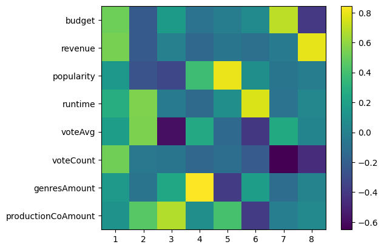

```python
import matplotlib.pyplot as plt
from matplotlib.backends import backend_agg

fig, ax = plt.subplots(nrows=1, ncols=1)
componentes = modelo_pca.components_
plt.imshow(componentes.T)
plt.yticks(range(len(df_numerical.columns)), df_numerical.columns)
plt.xticks(range(len(df_numerical.columns)), np.arange(modelo_pca.n_components_)+1)
plt.grid(False)
plt.colorbar()
```

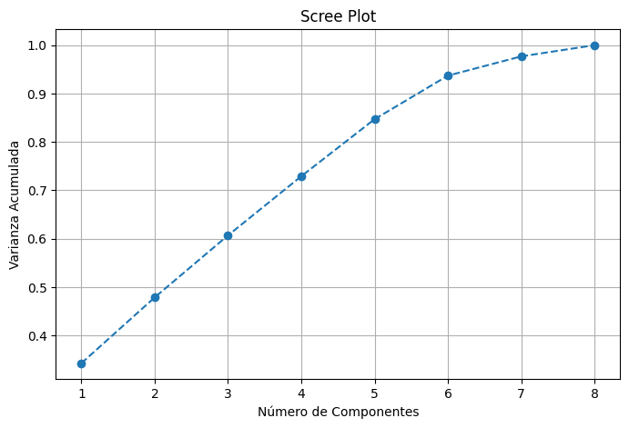

```python
import matplotlib.pyplot as plt
import numpy as np

explained_variance = modelo_pca.explained_variance_ratio_
cumulative_variance = np.cumsum(explained_variance)

plt.figure(figsize=(8,5))
plt.plot(range(1, len(explained_variance)+1), cumulative_variance, marker='o', linestyle='--')
plt.xlabel('Número de Componentes')
plt.ylabel('Varianza Acumulada')
plt.title('Scree Plot')
plt.grid(True)
plt.show()
```

```python
# Mostrar las cargas de los primeros 4 componentes
cargas = modelo_pca.components_[:4]

# Imprimir las cargas para interpretación
for i, carga in enumerate(cargas):
    print(f'Componente {i+1}:')
    for j, variable in enumerate(df_numerical.columns):
        print(f'  {variable}: {carga[j]:.3f}')
    print('---')
```

```
Componente 1:
  budget: 0.513
  revenue: 0.539
  popularity: 0.146
  runtime: 0.284
  voteAvg: 0.184
  voteCount: 0.522
  genresAmount: 0.153
  productionCoAmount: 0.119
---
Componente 2:
  budget: -0.224
  revenue: -0.225
  popularity: -0.268
  runtime: 0.557
  voteAvg: 0.549
  voteCount: -0.050
  genresAmount: -0.077
  productionCoAmount: 0.456
---
Componente 3:
  budget: 0.164
  revenue: -0.002
  popularity: -0.327
  runtime: -0.030
  voteAvg: -0.591
  voteCount: -0.070
  genresAmount: 0.249
  productionCoAmount: 0.670
---
Componente 4:
  budget: -0.082
  revenue: -0.151
  popularity: 0.380
  runtime: -0.131
  voteAvg: 0.252
  voteCount: -0.156
  genresAmount: 0.845
  productionCoAmount: 0.091
---
```